# Task 1

explore the data from "cwurData.csv", find the second strongest regressor for the world_rank (do not consider the broad_impact) build the regression model where world_rank is a dependent variable. visualize this regression using the matplotlib>

Note: Required "World Unversity Ranking" Datasets from Kaggle have been downloaded and saved into local system

```python
# Import Python Libraries

import numpy as np
import pandas as pd
import matplotlib.pyplot as plt
import seaborn as sns
import os
from sklearn.linear_model import LinearRegression
from sklearn.cross_validation import train_test_split
from sklearn.metrics import mean_squared_error
from sklearn.metrics import mean_absolute_error
%matplotlib inline
```

# Exploratory Data Analysis for "Center for World University Ranking" Data

```python
# Reading and bringing in data from "cwurData.csv" into a dataframe using pandas read_csv
df = pd.read_csv("cwurData.csv")
```

```python
#Checking total number of rows and columns in the dataset
df.shape
```

```
(2200, 14)
```

```python
# Looking at data sample by fetching first 10 rows
df.head(10)
```

|  | world_rank | institution | country | national_rank | quality_of_education | alumni_employment | quality_of_faculty | publications | influence | citations | broad_impact | patents | score | year |
| --- | --- | --- | --- | --- | --- | --- | --- | --- | --- | --- | --- | --- | --- | --- |
| 0 | 1 | Harvard University | USA | 1 | 7 | 9 | 1 | 1 | 1 | 1 | NaN | 5 | 100.00 | 2012 |
| 1 | 2 | Massachusetts Institute of Technology | USA | 2 | 9 | 17 | 3 | 12 | 4 | 4 | NaN | 1 | 91.67 | 2012 |
| 2 | 3 | Stanford University | USA | 3 | 17 | 11 | 5 | 4 | 2 | 2 | NaN | 15 | 89.50 | 2012 |
| 3 | 4 | University of Cambridge | United Kingdom | 1 | 10 | 24 | 4 | 16 | 16 | 11 | NaN | 50 | 86.17 | 2012 |
| 4 | 5 | California Institute of Technology | USA | 4 | 2 | 29 | 7 | 37 | 22 | 22 | NaN | 18 | 85.21 | 2012 |
| 5 | 6 | Princeton University | USA | 5 | 8 | 14 | 2 | 53 | 33 | 26 | NaN | 101 | 82.50 | 2012 |
| 6 | 7 | University of Oxford | United Kingdom | 2 | 13 | 28 | 9 | 15 | 13 | 19 | NaN | 26 | 82.34 | 2012 |
| 7 | 8 | Yale University | USA | 6 | 14 | 31 | 12 | 14 | 6 | 15 | NaN | 66 | 79.14 | 2012 |
| 8 | 9 | Columbia University | USA | 7 | 23 | 21 | 10 | 13 | 12 | 14 | NaN | 5 | 78.86 | 2012 |
| 9 | 10 | University of California, Berkeley | USA | 8 | 16 | 52 | 6 | 6 | 5 | 3 | NaN | 16 | 78.55 | 2012 |

```python
# Checking basic statistics about data in the dataset
df.describe()
```

|  | world_rank | national_rank | quality_of_education | alumni_employment | quality_of_faculty | publications | influence | citations | broad_impact | patents | score | year |
| --- | --- | --- | --- | --- | --- | --- | --- | --- | --- | --- | --- | --- |
| count | 2200.000000 | 2200.000000 | 2200.000000 | 2200.000000 | 2200.000000 | 2200.000000 | 2200.000000 | 2200.000000 | 2000.000000 | 2200.000000 | 2200.000000 | 2200.000000 |
| mean | 459.590909 | 40.278182 | 275.100455 | 357.116818 | 178.888182 | 459.908636 | 459.797727 | 413.417273 | 496.699500 | 433.346364 | 47.798395 | 2014.318182 |
| std | 304.320363 | 51.740870 | 121.935100 | 186.779252 | 64.050885 | 303.760352 | 303.331822 | 264.366549 | 286.919755 | 273.996525 | 7.760806 | 0.762130 |
| min | 1.000000 | 1.000000 | 1.000000 | 1.000000 | 1.000000 | 1.000000 | 1.000000 | 1.000000 | 1.000000 | 1.000000 | 43.360000 | 2012.000000 |
| 25% | 175.750000 | 6.000000 | 175.750000 | 175.750000 | 175.750000 | 175.750000 | 175.750000 | 161.000000 | 250.500000 | 170.750000 | 44.460000 | 2014.000000 |
| 50% | 450.500000 | 21.000000 | 355.000000 | 450.500000 | 210.000000 | 450.500000 | 450.500000 | 406.000000 | 496.000000 | 426.000000 | 45.100000 | 2014.000000 |
| 75% | 725.250000 | 49.000000 | 367.000000 | 478.000000 | 218.000000 | 725.000000 | 725.250000 | 645.000000 | 741.000000 | 714.250000 | 47.545000 | 2015.000000 |
| max | 1000.000000 | 229.000000 | 367.000000 | 567.000000 | 218.000000 | 1000.000000 | 991.000000 | 812.000000 | 1000.000000 | 871.000000 | 100.000000 | 2015.000000 |

```python
#Gathering more information on the data in the dataset so as to see data types of attributes
#It also helps to check if the attributes have any missing values
df.info()
```

```
<class 'pandas.core.frame.DataFrame'>
RangeIndex: 2200 entries, 0 to 2199
Data columns (total 14 columns):
world_rank              2200 non-null int64
institution             2200 non-null object
country                 2200 non-null object
national_rank           2200 non-null int64
quality_of_education    2200 non-null int64
alumni_employment       2200 non-null int64
quality_of_faculty      2200 non-null int64
publications            2200 non-null int64
influence               2200 non-null int64
citations               2200 non-null int64
broad_impact            2000 non-null float64
patents                 2200 non-null int64
score                   2200 non-null float64
year                    2200 non-null int64
dtypes: float64(2), int64(10), object(2)
memory usage: 240.7+ KB
```

From the above information retreived about 'Center for World University Rankings' Data,we can clearly see that there are no missing values in any of the attributes except in the attribute named 'broad_impact' which has 200 rows having NaNs.Apart from this issue,all the attributes are having appropriate data types in accordance with data they contain.

Therefore,there is a need to perform 'Data Cleansing' step to handle missing values in 'broad_impact'.

## Data Cleansing/Data Preparation Steps

We need to prepare data in 'broad_impact' feature by replacing or imputing NaNs/Nulls by average value for this attribute across years for a particular university.We will further replace still remaining Null or NaN with 0 for those institutions which have NaNs/Null across years.

```python
df['broad_impact']=df['broad_impact'].fillna(df.groupby(['institution'])['broad_impact'].transform('mean'))
df['broad_impact']=df['broad_impact'].fillna(0)
#df.broad_impact[df['institution']=='Harvard University']
```

[output not shown]

```python
#Checking the information on dataset once again to validate impact of data cleansing
df.info()
```

```
<class 'pandas.core.frame.DataFrame'>
RangeIndex: 2200 entries, 0 to 2199
Data columns (total 14 columns):
world_rank              2200 non-null int64
institution             2200 non-null object
country                 2200 non-null object
national_rank           2200 non-null int64
quality_of_education    2200 non-null int64
alumni_employment       2200 non-null int64
quality_of_faculty      2200 non-null int64
publications            2200 non-null int64
influence               2200 non-null int64
citations               2200 non-null int64
broad_impact            2200 non-null float64
patents                 2200 non-null int64
score                   2200 non-null float64
year                    2200 non-null int64
dtypes: float64(2), int64(10), object(2)
memory usage: 240.7+ KB
```

Here we can clearly see that 'broad_impact shows 2200 non-null rows and therefore the problem of NaNs/missing data has been rectified.

#### Generic setting for all upcoming visualizations

```python
# Settings to switch -off the grid lines and making background white for all visualizations using seaborn
sns.set_style("white")
```

## Let's set up some visualizations to understand the data better

As a first step, we will start by analysing distribution of values for each of the attribute.This will help us understand which features have outliers towards higher or lower side.

```
array([[<matplotlib.axes._subplots.AxesSubplot object at 0x000000000E2F6128>,
      dtype=object)
```

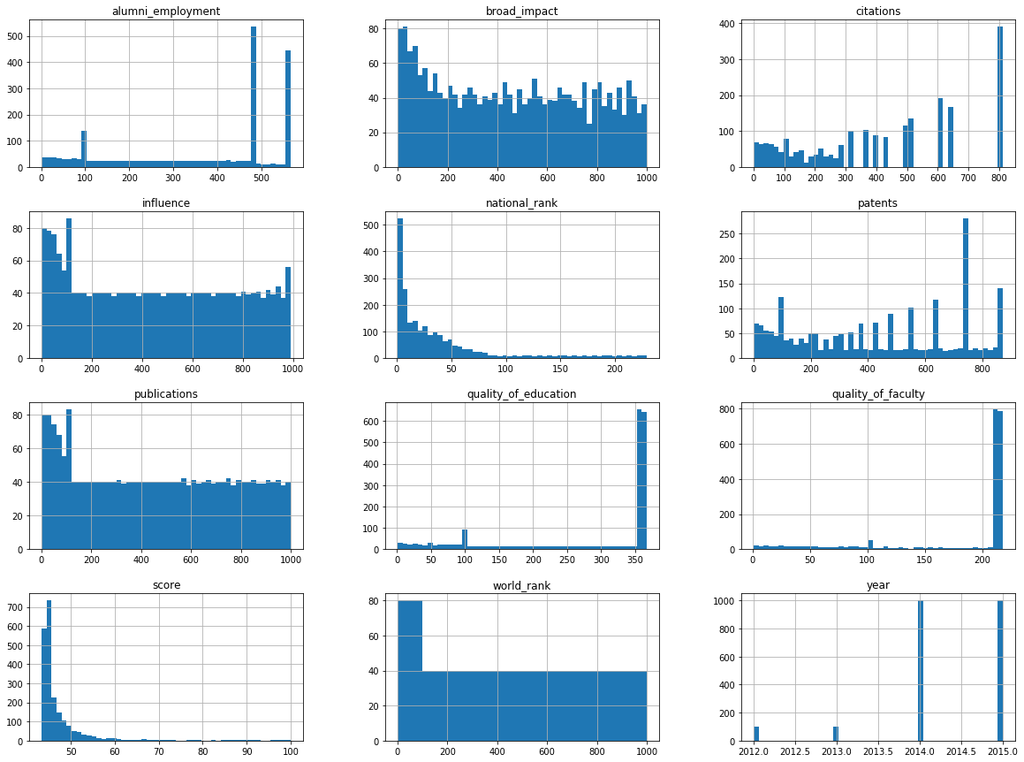

```python
df.hist(bins=50, figsize=(20,15))
```

### Evaluation of no. of universities which participated in survey each year

```python
df['year'].value_counts().sort_values(ascending=True)
```

```
2013     100
2012     100
2015    1000
2014    1000
Name: year, dtype: int64
```

### Changes in Ranking of Top 10 universities across years

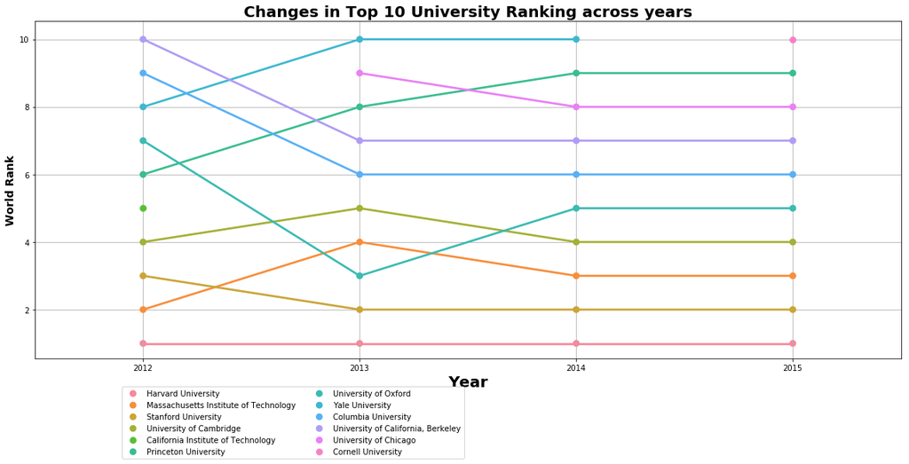

```python
Top10Universities_EachYear=df[['year','institution','world_rank']].groupby('year').head(10)
# Using seaborn library of Python for visualizing by means of a pointplot
plt.figure(figsize=(20,8))
ax=sns.pointplot(data=Top10Universities_EachYear, x="year", y="world_rank",hue="institution",marker='o')
ax.grid(True)
plt.title('Changes in Top 10 University Ranking across years',fontsize=20,fontweight='bold')
plt.xlabel('Year',fontsize=20,fontweight='bold')
plt.ylabel('World Rank',fontsize=14,fontweight='bold')
plt.legend(loc='upper right', bbox_to_anchor=(0.5, -0.07), ncol=2)
```

It can be clearly seen that "Harvard University" has maintained its no.1 rank across years as by CWUR survey.

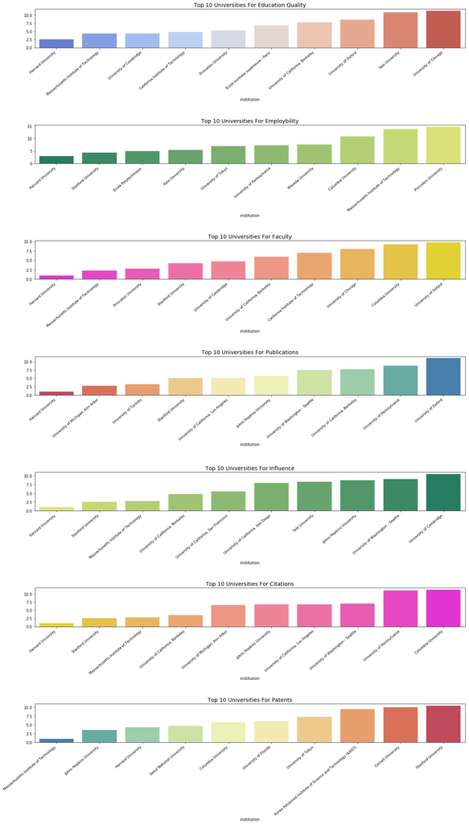

```python
#We will be creating sub-plots here and calculate by taking mean value across years
#Smallest Rank is for best University
Top10UniversitiesEduQuality = df.groupby('institution')['quality_of_education'].mean().nsmallest(10)
Top10UniversitiesForEmployment = df.groupby('institution')['alumni_employment'].mean().nsmallest(10)
Top10UniversitiesForFaculty = df.groupby('institution')['quality_of_faculty'].mean().nsmallest(10)
Top10UniversitiesForPublications = df.groupby('institution')['publications'].mean().nsmallest(10)
Top10UniversitiesForInfluence = df.groupby('institution')['influence'].mean().nsmallest(10)
Top10UniversitiesForCitations = df.groupby('institution')['citations'].mean().nsmallest(10)
Top10UniversitiesForPatents = df.groupby('institution')['patents'].mean().nsmallest(10)

fig, axarr = plt.subplots(7, 1, figsize=(20,35))
sns.barplot(Top10UniversitiesEduQuality.index, Top10UniversitiesEduQuality.values,orient='v', ax=axarr[0],palette='coolwarm')
axarr[0].set_title("Top 10 Universities For Education Quality", fontsize=14)
axarr[0].set_xticklabels(Top10UniversitiesEduQuality.index, rotation=40, ha="right",fontsize=9)
sns.barplot(Top10UniversitiesForEmployment.index, Top10UniversitiesForEmployment.values,orient='v', ax=axarr[1],palette='summer')
axarr[1].set_title("Top 10 Universities For Employbility", fontsize=14)
axarr[1].set_xticklabels(Top10UniversitiesForEmployment.index, rotation=40, ha="right",fontsize=9)
sns.barplot(Top10UniversitiesForFaculty.index, Top10UniversitiesForFaculty.values,orient='v', ax=axarr[2],palette='spring')
axarr[2].set_title("Top 10 Universities For Faculty", fontsize=14)
axarr[2].set_xticklabels(Top10UniversitiesForFaculty.index, rotation=40, ha="right",fontsize=9)
sns.barplot(Top10UniversitiesForPublications.index, Top10UniversitiesForPublications.values,orient='v', ax=axarr[3],palette='Spectral')
axarr[3].set_title("Top 10 Universities For Publications", fontsize=14)
axarr[3].set_xticklabels(Top10UniversitiesForPublications.index, rotation=40, ha="right",fontsize=9)
sns.barplot(Top10UniversitiesForInfluence.index, Top10UniversitiesForInfluence.values,orient='v', ax=axarr[4],palette='summer_r')
axarr[4].set_title("Top 10 Universities For Influence", fontsize=14)
axarr[4].set_xticklabels(Top10UniversitiesForInfluence.index, rotation=40, ha="right",fontsize=9)
sns.barplot(Top10UniversitiesForCitations.index, Top10UniversitiesForCitations.values,orient='v', ax=axarr[5],palette='spring_r')
axarr[5].set_title("Top 10 Universities For Citations", fontsize=14)
axarr[5].set_xticklabels(Top10UniversitiesForCitations.index, rotation=40, ha="right",fontsize=9)
sns.barplot(Top10UniversitiesForPatents.index, Top10UniversitiesForPatents.values,orient='v', ax=axarr[6],palette='Spectral_r')
axarr[6].set_title("Top 10 Universities For Patents", fontsize=14)
axarr[6].set_xticklabels(Top10UniversitiesForPatents.index, rotation=40, ha="right",fontsize=9)
plt.subplots_adjust(hspace=2)
```

#### We will now analyze relation between feature variables and dependent variable present in this dataset.

We will begin with analyzing relationsip between score,national_rank and world_rank

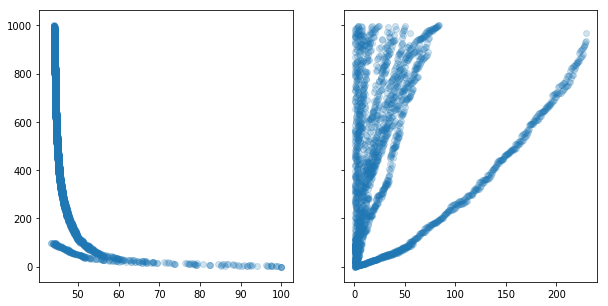

```python
fig, (ax1,ax2) = plt.subplots(1, 2, figsize=(10,5), sharey=True)
ax1.scatter(data=df, x="score", y="world_rank", alpha=0.2)
ax2.scatter(data=df, x="national_rank", y="world_rank", alpha=0.2)
```

#### Lets collectively see how world_rank is related to other feature variables by means of a scattter matrix

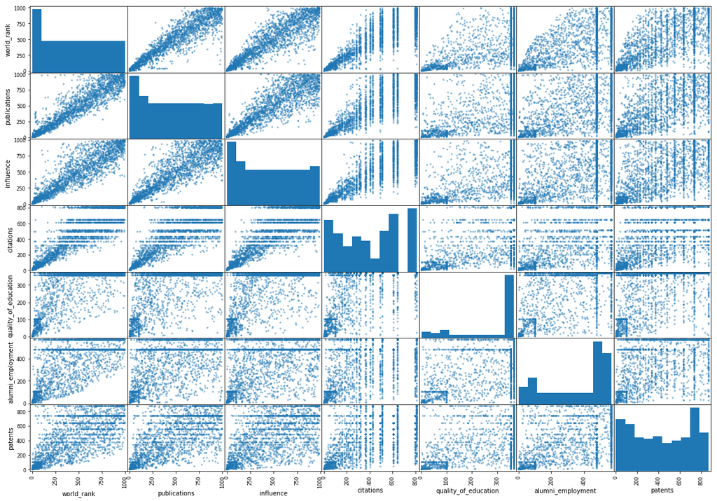

```python
from pandas.plotting import scatter_matrix
attributes = ["world_rank", "publications", "influence", "citations","quality_of_education","alumni_employment","patents"]
scatter_matrix(df[attributes], figsize=(20, 14))
plt.savefig('matrix.png')
```

This shows that world rank is more correlated with publications and influence than other feature variables.Here we have not considered broad_impact as has been asked in the question. Other point to be noted is that quality_of_education,alumni_employement and patents have lots of ouliers which are preventing a good linear fit in regression plot with world_rank.

```python
# Let's see the correlation matrix
corr_matrix=df.corr()
corr_matrix
```

|  | world_rank | national_rank | quality_of_education | alumni_employment | quality_of_faculty | publications | influence | citations | broad_impact | patents | score | year |
| --- | --- | --- | --- | --- | --- | --- | --- | --- | --- | --- | --- | --- |
| world_rank | 1.000000 | 0.238553 | 0.676166 | 0.668529 | 0.663864 | 0.923037 | 0.895871 | 0.856573 | 0.949707 | 0.698214 | -0.549098 | 0.320844 |
| national_rank | 0.238553 | 1.000000 | 0.211975 | 0.135342 | 0.222833 | 0.326857 | 0.161086 | 0.186797 | 0.210021 | 0.159440 | -0.199756 | 0.102951 |
| quality_of_education | 0.676166 | 0.211975 | 1.000000 | 0.606421 | 0.786181 | 0.624657 | 0.645641 | 0.630455 | 0.616337 | 0.528120 | -0.600541 | 0.427732 |
| alumni_employment | 0.668529 | 0.135342 | 0.606421 | 1.000000 | 0.558618 | 0.572096 | 0.527382 | 0.559200 | 0.531193 | 0.528219 | -0.510374 | 0.427710 |
| quality_of_faculty | 0.663864 | 0.222833 | 0.786181 | 0.558618 | 1.000000 | 0.634423 | 0.656406 | 0.652186 | 0.638096 | 0.555107 | -0.693540 | 0.484788 |
| publications | 0.923037 | 0.326857 | 0.624657 | 0.572096 | 0.634423 | 1.000000 | 0.874952 | 0.829912 | 0.929441 | 0.671558 | -0.522111 | 0.318245 |
| influence | 0.895871 | 0.161086 | 0.645641 | 0.527382 | 0.656406 | 0.874952 | 1.000000 | 0.845207 | 0.928114 | 0.611811 | -0.522837 | 0.318298 |
| citations | 0.856573 | 0.186797 | 0.630455 | 0.559200 | 0.652186 | 0.829912 | 0.845207 | 1.000000 | 0.876096 | 0.598728 | -0.522438 | 0.328771 |
| broad_impact | 0.949707 | 0.210021 | 0.616337 | 0.531193 | 0.638096 | 0.929441 | 0.928114 | 0.876096 | 1.000000 | 0.636483 | -0.528399 | 0.305241 |
| patents | 0.698214 | 0.159440 | 0.528120 | 0.528219 | 0.555107 | 0.671558 | 0.611811 | 0.598728 | 0.636483 | 1.000000 | -0.474810 | 0.368570 |
| score | -0.549098 | -0.199756 | -0.600541 | -0.510374 | -0.693540 | -0.522111 | -0.522837 | -0.522438 | -0.528399 | -0.474810 | 1.000000 | -0.239136 |
| year | 0.320844 | 0.102951 | 0.427732 | 0.427710 | 0.484788 | 0.318245 | 0.318298 | 0.328771 | 0.305241 | 0.368570 | -0.239136 | 1.000000 |

#### Let's see this correlation matrix in more readable for by plotting it on a heatmap

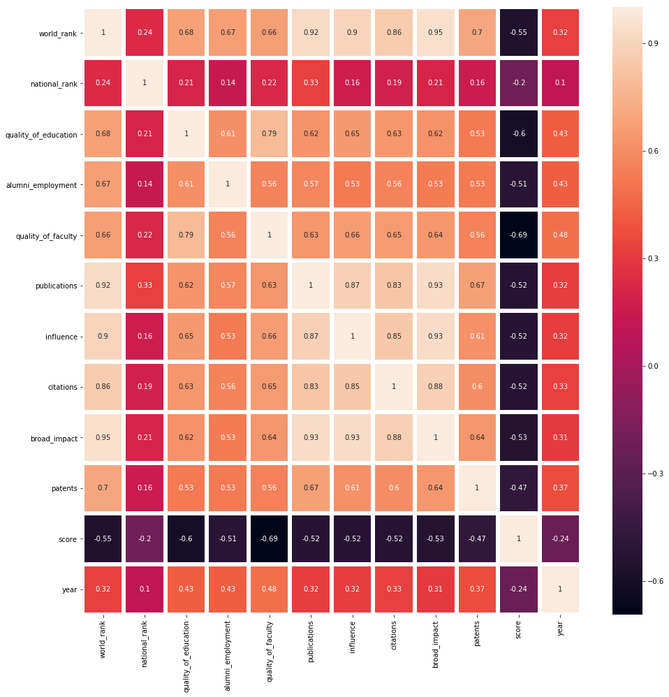

```python
f,ax = plt.subplots(figsize=(16,16))
sns.heatmap(corr_matrix,annot=True,linewidths=5,ax=ax)
plt.show()
```

#### Let us see strongest and weakest regressors for 'world_rank' in a ordered format

```python
corr_matrix["world_rank"].sort_values(ascending=False)
```

```
world_rank              1.000000
broad_impact            0.949707
publications            0.923037
influence               0.895871
citations               0.856573
patents                 0.698214
quality_of_education    0.676166
alumni_employment       0.668529
quality_of_faculty      0.663864
year                    0.320844
national_rank           0.238553
score                  -0.549098
Name: world_rank, dtype: float64
```

Since,we have been asked to ignore 'broad_impact',therefore 2nd strongest regressors appears to be 'publications'.The same was eveident in the correlation heatmap.

## We will now start to develop our regression model

#### First Regression model using scikit learn or sklearn

```python
# Picking the dependent and indepedent variable/regressor
X_Reg = df['publications'].values
Y_Target = df['world_rank'].values
```

```python
# Coverting X_Reg and Y_Target into a 2D format so that they can be used with scikit learn regression model
X_Reg = X_Reg.reshape(len(X_Reg),1)
Y_Target= Y_Target.reshape(len(Y_Target),1)
```

```python
# Splitting the data into train and test sets in 70 : 30 ratio
X_train, X_test, Y_train, Y_test = train_test_split(X_Reg, Y_Target, test_size=0.3, random_state=0)
regressor = LinearRegression()
regressor.fit(X_train, Y_train)
```

```
LinearRegression(copy_X=True, fit_intercept=True, n_jobs=1, normalize=False)
```

```python
print('Coefficient:' , regressor.coef_)
print('Interceptn:' , regressor.intercept_)
```

```
Coefficient: [[0.92663174]]
Interceptn: [34.88629156]
```

```python
Y_Pred = regressor.predict(X_test)
print('Linear Regression R squared: %.2f' % regressor.score(X_test, Y_test))
```

```
Linear Regression R squared: 0.85
```

So, in our model, 85.18% of the variability in Y can be explained using X. Now we will calculate root-mean-square error (RMSE)

```python
mse = mean_squared_error(Y_Pred, Y_test)
rmse = np.sqrt(mse)
print('Linear Regression RMSE: %.2f' % rmse)
```

```
Linear Regression RMSE: 117.00
```

```python
mae = mean_absolute_error(Y_Pred, Y_test)
print('Linear Regression MAE: %.2f' % mae)
```

```
Linear Regression MAE: 81.13
```

Visualizing how well our the regression model we built fits within the refression line

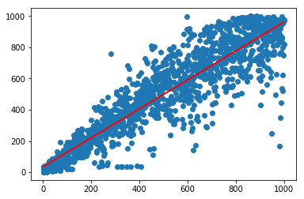

```python
plt.scatter(X_train, Y_train)
plt.plot(X_test, Y_Pred, color='red')
plt.show()
```

# Regression using Statsmodel

```python
import statsmodels.api as sm
from statsmodels.sandbox.regression.predstd import wls_prediction_std
```

```python
x=df['publications']
y=df['world_rank']
x = sm.add_constant(x) #adding constant for intercept
```

```python
model = sm.OLS(y, x).fit() ## sm.OLS(output, input)
predictions = model.predict(x)
# Print out the statistics
model.summary()
```

OLS Regression Results

| Dep. Variable: | world_rank | R-squared: | 0.852 |
| --- | --- | --- | --- |
| Model: | OLS | Adj. R-squared: | 0.852 |
| Method: | Least Squares | F-statistic: | 1.265e+04 |
| Date: | Tue, 17 Jul 2018 | Prob (F-statistic): | 0.00 |
| Time: | 20:36:44 | Log-Likelihood: | -13599. |
| No. Observations: | 2200 | AIC: | 2.720e+04 |
| Df Residuals: | 2198 | BIC: | 2.721e+04 |
| Df Model: | 1 |  |  |
| Covariance Type: | nonrobust |  |  |

|  | coef | std err | t | P>\|t\| | [0.025 | 0.975] |
| --- | --- | --- | --- | --- | --- | --- |
| const | 34.2956 | 4.531 | 7.569 | 0.000 | 25.410 | 43.181 |
| publications | 0.9247 | 0.008 | 112.486 | 0.000 | 0.909 | 0.941 |

| Omnibus: | 381.096 | Durbin-Watson: | 1.618 |
| --- | --- | --- | --- |
| Prob(Omnibus): | 0.000 | Jarque-Bera (JB): | 1918.071 |
| Skew: | -0.729 | Prob(JB): | 0.00 |
| Kurtosis: | 7.336 | Cond. No. | 1.00e+03 |

Warnings:  
[1] Standard Errors assume that the covariance matrix of the errors is correctly specified.  
[2] The condition number is large, 1e+03. This might indicate that there are  
strong multicollinearity or other numerical problems.

```
Coefficient: [[0.92663174]]
Intercept: [34.88629156]
Linear Regression R squared: 0.85
Linear Regression RMSE: 117.00
Linear Regression MAE: 81.13
```

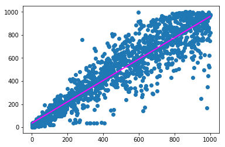

```python
def answer_four():
    df = pd.read_csv("cwurData.csv")
    df.head()
    X_Reg = df['publications'].values
    Y_Target = df['world_rank'].values
    X_Reg = X_Reg.reshape(len(X_Reg),1)
    Y_Target= Y_Target.reshape(len(Y_Target),1)
    X_train, X_test, Y_train, Y_test = train_test_split(X_Reg, Y_Target, test_size=0.3, random_state=0)
    regressor = LinearRegression()
    regressor.fit(X_train, Y_train)
    print('Coefficient:' , regressor.coef_)
    print('Intercept:' , regressor.intercept_)
    Y_Pred = regressor.predict(X_test)
    print('Linear Regression R squared: %.2f' % regressor.score(X_test, Y_test))
    mse = mean_squared_error(Y_Pred, Y_test)
    rmse = np.sqrt(mse)
    print('Linear Regression RMSE: %.2f' % rmse)
    mae = mean_absolute_error(Y_Pred, Y_test)
    print('Linear Regression MAE: %.2f' % mae)
    plt.scatter(X_train, Y_train)
    plt.plot(X_test, Y_Pred, color='magenta')
    plt.show()
    return None
answer_four()
```

***Completion of Task**